# Progesterone receptor status and differentiation grade in infiltrating duct and lobular carcinoma breast cancer

Author

Luca Sung Rok Shin (550846268)

# 1 Client Bio

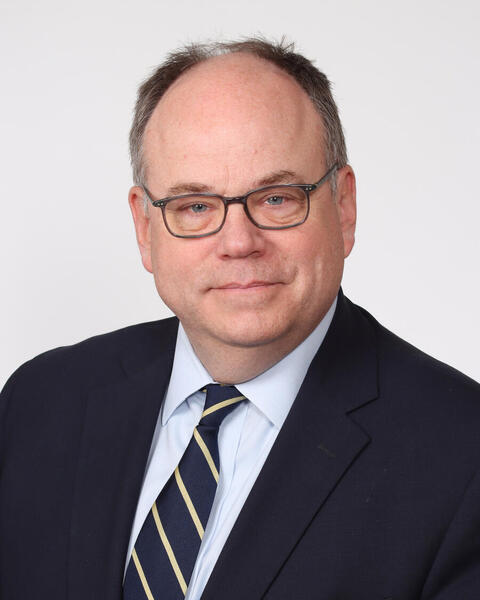

**Matthew P. Goetz, M.D. | [Profile](https://www.mayo.edu/research/faculty/goetz-matthew-p-m-d/bio-00027285)**

*Mayo Clinic Cancer Center Deputy Director of Translational Research*

Dr Goetz’s clinical and laboratory research focuses on individualised therapeutics and the pharmacogenetics of tamoxifen for estrogen positive (ER+) breast cancer. He also produces translational research which improves patient outcomes, aiming to increase survival rates for rarer forms of breast cancer.

# 2 Recommendation

- Increase research in individualised therapeutics and tamoxifen alternatives as PR- cancers are associated with low DG, poor prognosis.
- Produce translational research in implications of PR- breast cancer patients in a clinical setting.
- Push for considering PR status to change individual treatment plans as it has high prognostic value regarding DG.

# 3 Evidence

```r
library(ggplot2)
library(plotly)
library(ggpubr)
library(dplyr)
library(tidyverse)
library(vcd)
theme_set(theme_bw())

df = read.csv("breast_cancer.csv") |>
  drop_na()

Finaldf = df |>
  mutate(
    Grade = str_replace(Grade, "anaplastic; Grade IV", "4"),
    Grade = as.numeric(Grade),
    Progesterone.Status = as.factor(Progesterone.Status),
    Grade_highlow = case_when(
      Grade >= 3 ~ "Low",
      TRUE ~ "High")
    )

## low differentiation = poorly + undifferentiated (grade 3 and 4)
LD = filter(Finaldf, Grade == 3 & 4)
## high differentiation = well + moderately differentiated (grade 1 and 2)
HD = filter(Finaldf, Grade == 1 & 2)

PE = filter(Finaldf, Estrogen.Status == "Positive")
NE = filter(Finaldf, Estrogen.Status == "Negative")

## stratified for positive estrogen
## low differentiation and positive progesterone
LDPPPE = filter(LD, Progesterone.Status == "Positive", Estrogen.Status == "Positive")
mLDPPPE = length(LDPPPE$Progesterone.Status)
## low differentiation and negative progesterone
LDNPPE = filter(LD, Progesterone.Status == "Negative", Estrogen.Status == "Positive")
mLDNPPE = length(LDNPPE$Progesterone.Status)
## high differentiation and positive progesterone
HDPPPE = filter(HD, Progesterone.Status == "Positive", Estrogen.Status == "Positive")
mHDPPPE = length(HDPPPE$Progesterone.Status)
## high differentiation and negative progesterone
HDNPPE = filter(HD, Progesterone.Status == "Negative", Estrogen.Status == "Positive")
mHDNPPE = length(HDNPPE$Progesterone.Status)

## stratified for negative estrogen
## low differentiation and positive progesterone
LDPPNE = filter(LD, Progesterone.Status == "Positive", Estrogen.Status == "Negative")
mLDPPNE = length(LDPPNE$Progesterone.Status)
## low differentiation and negative progesterone
LDNPNE = filter(LD, Progesterone.Status == "Negative", Estrogen.Status == "Negative")
mLDNPNE = length(LDNPNE$Progesterone.Status)
## high differentiation and positive progesterone
HDPPNE = filter(HD, Progesterone.Status == "Positive", Estrogen.Status == "Negative")
mHDPPNE = length(HDPPNE$Progesterone.Status)
## high differentiation and negative progesterone
HDNPNE = filter(HD, Progesterone.Status == "Negative", Estrogen.Status == "Negative")
mHDNPNE = length(HDNPNE$Progesterone.Status)
```

## 3.1 Visual analysis

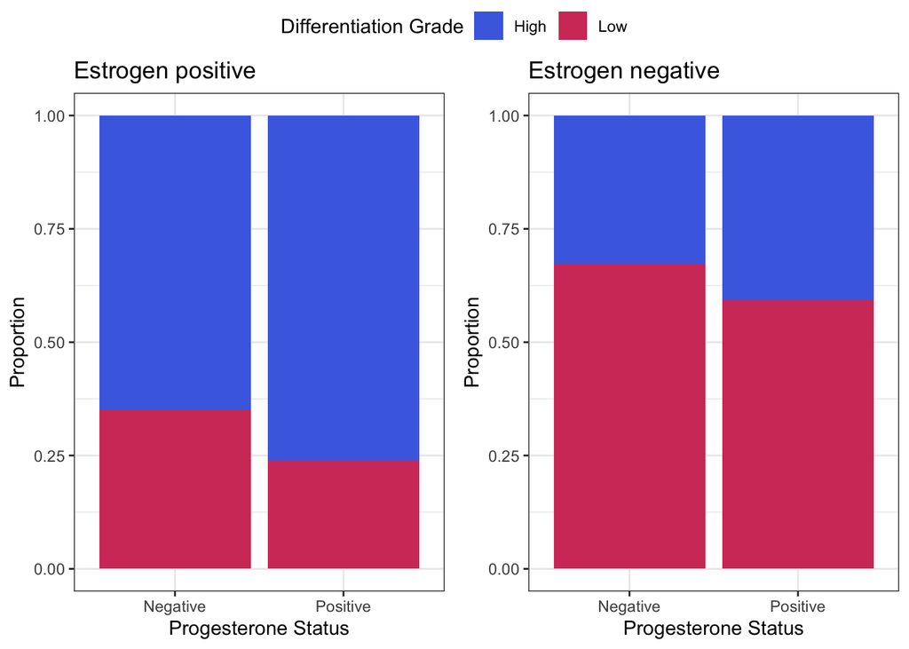

```r
bara = ggplot(PE, aes(fill = Grade_highlow, x = Progesterone.Status)) +
  geom_bar(position = "fill") +
  labs(title = "Estrogen positive", x = "Progesterone Status", y = "Proportion") +
  scale_fill_manual(name = "Differentiation Grade", values = c("#4b6ee3", "#d33f68"), labels = c("High", "Low"))
barb = ggplot(NE, aes(fill = Grade_highlow, x = Progesterone.Status)) +
  geom_bar(position = "fill") +
  labs(title = "Estrogen negative", x = "Progesterone Status", y = "Proportion") +
  scale_fill_manual(name = "Differentiation Grade", values = c("#4b6ee3", "#d33f68"), labels = c("High", "Low"))
ggarrange(bara, barb, common.legend = TRUE)
```

*Figure 1: Barplot showing proportion of subjects with high and low DG for +/- PR status, stratified for ER status*

Focusing on the dependence of DG and PR status, at first glance, Figure 1 shows a decrease in low DG for PR+ vs PR- breast cancers stratified for ER +/- samples.

## 3.2 Hypothesis testing I

```r
Progesterone.in = array(c(mLDPPPE, mLDNPPE, mHDPPPE, mHDNPPE, mLDPPNE, mLDNPNE, mHDPPNE, mHDNPNE), dim = c(2, 2, 2), dimnames = list(Differentiability = c("Low", "High"), Progesterone_Status = c("Positive", "Negative"), Estrogen_Status = c("Positive", "Negative")))

Progesterone = as.table(Progesterone.in)
```

Hypothesis testing was done through the $\chi^2$ test of independence by constructing a 2x2 contingency table. All cells were filled with >5 frequency, satisfying Cochran’s rule. Observations are independent given the nature of dataset.

**H<sub>0</sub>**: Differentiation grade is independent to progesterone status

**H<sub>1</sub>**: Differentiation grade is not independent to progesterone status

```r
Chisquare = chisq.test(table(Finaldf$Progesterone.Status, Finaldf$Grade_highlow))
Assocstats = assocstats(table(Finaldf$Progesterone.Status, Finaldf$Grade_highlow))

Chisquare
```

```
    Pearson's Chi-squared test with Yates' continuity correction

data:  table(Finaldf$Progesterone.Status, Finaldf$Grade_highlow)
X-squared = 137.32, df = 1, p-value < 2.2e-16
```

```r
Assocstats
```

```
                    X^2 df P(> X^2)
Likelihood Ratio 128.66  1        0
Pearson          138.41  1        0

Phi-Coefficient   : 0.185
Contingency Coeff.: 0.182
Cramer's V        : 0.185
```

A p-value < 2.2e-16 means we can reject the null hypothesis, at $\alpha = 0.01$. This indicates a highly significant statistical association and dependence between PR status and DG. A phi coefficient of 0.185 indicates weak positive correlation, where PR+ cancers have higher DG and thus better prognosis. It was suspected that ER status may be a confounding variable given its long-established status as predictor for tumour aggressiveness and survival rate (Payne *et al*., 2007).

## 3.3 Hypothesis testing II

To mitigate possible occurrence of Simpson’s Paradox with ER status a confounding variable, the Cochran–Mantel–Haenszel $\chi^2$ test was conducted, constructing two strata for ER+/- samples. Independence is assumed.

**H<sub>0</sub>**: Odds ratio (of relative risk) between PR status and DG varying across the strata = 1; ie no association when stratified

**H<sub>1</sub>**: Odds ratio between PR status and DG varying across the strata ≠ 1; ie statistically significant association when stratified

```r
Mantelhaen = mantelhaen.test(Progesterone)
Mantelhaen
```

```
    Mantel-Haenszel chi-squared test with continuity correction

data:  Progesterone
Mantel-Haenszel X-squared = 25.977, df = 1, p-value = 3.455e-07
alternative hypothesis: true common odds ratio is not equal to 1
95 percent confidence interval:
 0.281442 0.572844
sample estimates:
common odds ratio
         0.401525
```

The 95% confidence interval for odds ratio ($\frac{\text{odds of high DG in PR-}}{\text{odds of high DG in PR+}}$) does not include 1, which means null hypothesis is rejected. Thus, dependence between PR status and DG is statistically significant, even after adjusting for the ER status.

## 3.4 Pearson Residuals

**Mosaic plot**

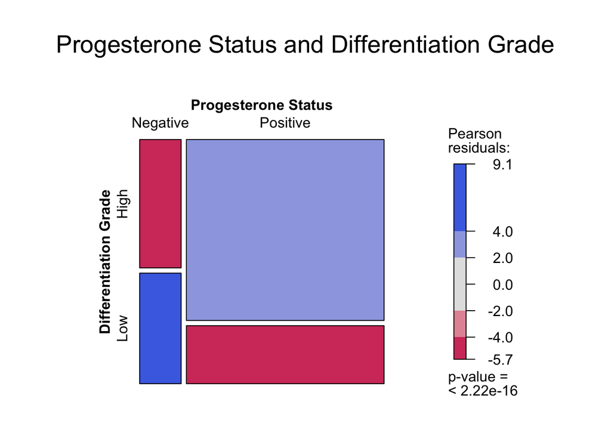

```r
largs = list(set_varnames = list(Progesterone.Status = "Progesterone Status",
                                 Grade_highlow = "Differentiation Grade"))

progesteronemosaic = mosaic(~ Progesterone.Status + Grade_highlow,
  direction = c("v", "h"),
  data = Finaldf,
  shade = TRUE,
  main = "Progesterone Status and Differentiation Grade",
  labeling_args = largs
)
```

**Contingency table, without stratification**

```r
table(Finaldf$Progesterone.Status, Finaldf$Grade_highlow)
```

```
           High  Low
  Negative  375  323
  Positive 2519  807
```

*Figure 2: Mosaic plot with Pearson residuals for PR status and DG (tab 1), raw contingency table without stratification (tab 2)*

A mosaic plot with Pearson residuals was created from analysis conducted in 3.2. Shading is present in each cell, reinforcing the conclusion that dependence is statistically significant. Most significantly, PR- is associated with low DG and vice versa, as indicated by strongly positive residual values. This conforms to literature, as ER+/PR- tumours were associated with higher tumour grade (i.e. low DG) amongst other markers of poor prognosis. This implies PR- cancers should be treated differently as it has prognostic value (Ponzone *et al.*, 2006).

## 3.5 Limitations

- Other potential confounding variables such as race and age were not stratified in 3.3; Simpson’s Paradox may occur.
- Literature found HER2 receptor status associated with DG (Rodrigues I. *et al*., 2024), but was not in dataset.
- Population studies insufficient to fully inform individualised treatment, as breast cancer is highly heterogeneous (Parise CA. *et al*., 2009) and requires consideration on case-by-case basis.

# 4 Ethics Statement

**Truthfulness and Integrity:** no external funding was received for this report, all methodologies and code were elucidated for transparency, and no data was tampered with from the original dataset

**Protecting the Interests of Subjects:** all patient information remained confidential and database contained no identifiable information

# 5 AI usage statement

1. ChatGPT, GPT4o-mini, 16 May 2025, https://chatgpt.com/share/6826fb80-de28-8000-aa3d-96db4be2b79b

   Used it to clarify the significance of confidence interval of true common odds ratio including 1 (relevant to 3.3, Cochran–Mantel–Haenszel Chi-squared test). Used for confirming not as an original source of information (see Acknowledgements, Cochran-Mantel-Haenszel Test concepts)

# 6 References

Parise CA., Bauer KR., Brown MM. *et al*. Breast Cancer Subtypes as Defined by the Estrogen Receptor (ER), Progesterone Receptor (PR), and the Human Epidermal Growth Factor Receptor 2 (HER2) among Women with Invasive Breast Cancer in California, 1999–2004. *The Breast Journal* (2009). https://doi.org/10.1111/j.1524-4741.2009.00822.x

Payne SJL., Bowel RL., Jones JL. *et al*. Predictive markers in breast cancer – the present. *Histopathology* **52**, 82-90 (2007). https://doi.org/10.1111/j.1365-2559.2007.02897.x

Ponzone R., Montemurro F., Maggiorotto F. *et al*. Clinical outcome of adjuvant endocrine treatment according to PR and HER-2 status in early breast cancer. *Annals of Oncology* **17**, 1631-1636 (2006). https://doi.org/10.1093/annonc/mdl296

Rodrigues I., Fernandes R., Ferreira A. *et al*. Is Progesterone Receptor a Neglected Feature in Breast Cancer? A Retrospective Study Analysing the Clinicopathological Characteristics of Breast Cancer Based on Progesterone Receptor Status. *Clinical Breast Cancer* (2024). https://doi.org/10.1016/j.clbc.2024.11.018

# 7 Acknowledgements

Data source: https://ieee-dataport.org/open-access/seer-breast-cancer-data

Mosaics: https://cran.r-project.org/web/packages/vcdExtra/vignettes/mosaics.html

Cochran-Mantel-Haenszel Test in R: https://stats.stackexchange.com/questions/25082/calculate-mantel-haenszel-test-in-r

Cochran-Mantel-Haenszel Test concepts: https://stats.libretexts.org/Bookshelves/Applied_Statistics/Biological_Statistics_(McDonald)/02%3A_Tests_for_Nominal_Variables/2.10%3A_Cochran-Mantel-Haenszel_Test

https://rpubs.com/abova/cmh

Using ggarrange: https://rpkgs.datanovia.com/ggpubr/reference/ggarrange.html

Assocstats: https://www.rdocumentation.org/packages/vcd/versions/1.4-13/topics/assocstats

Phi coefficient: https://www.r-bloggers.com/2021/07/how-to-calculate-phi-coefficient-in-r/

Case_when (dplyr package): https://www.rdocumentation.org/packages/dplyr/versions/0.7.1/topics/case_when

Matthew Goetz biography: https://www.mayo.edu/research/faculty/goetz-matthew-p-m-d/bio-00027285